# Coronavirus v Čechách

# Základní statistiky

## Testy

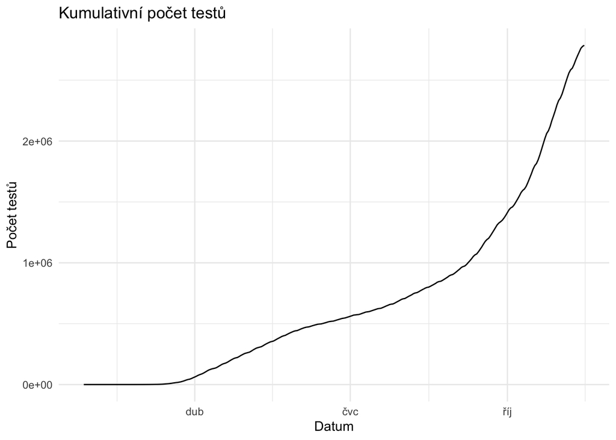

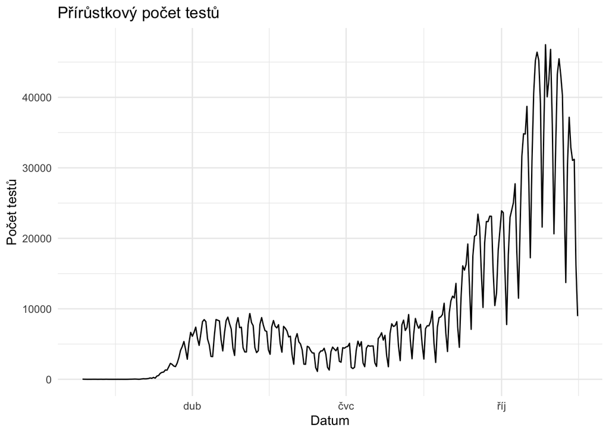

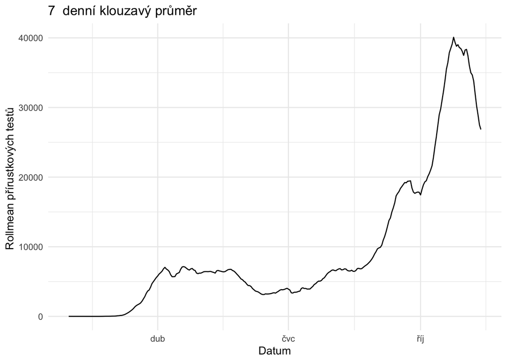

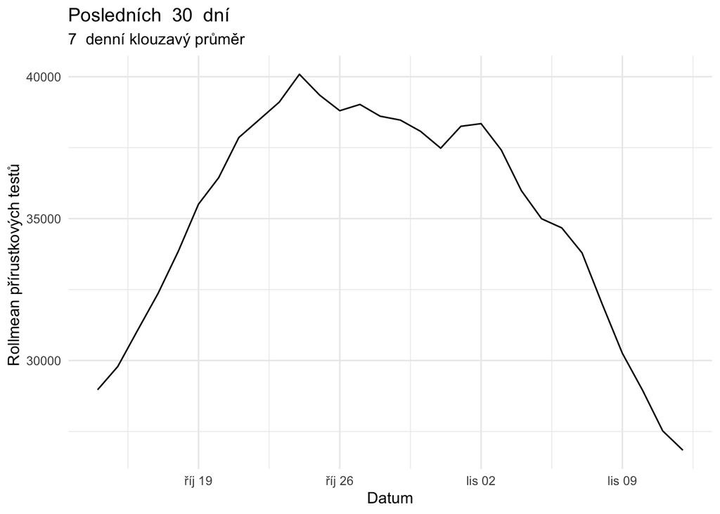

## Pozitivní případy

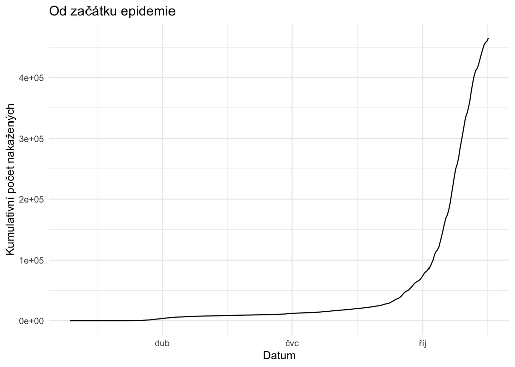

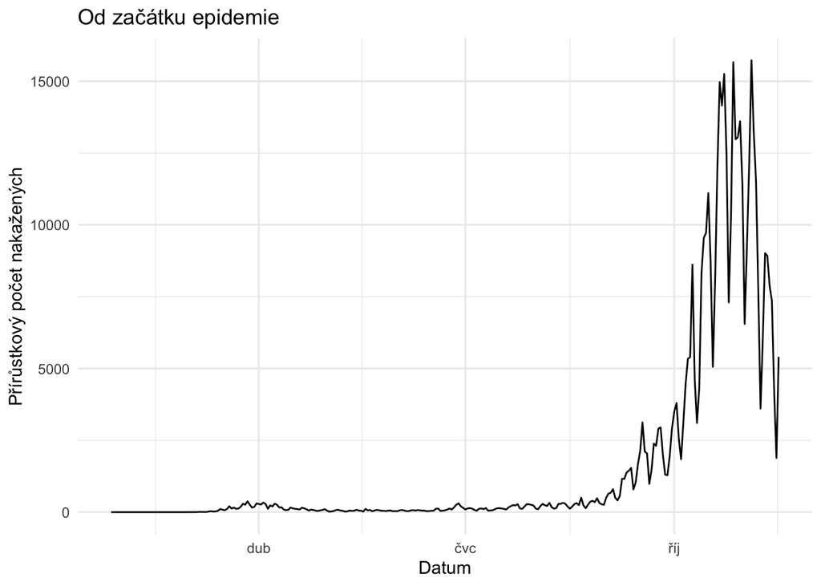

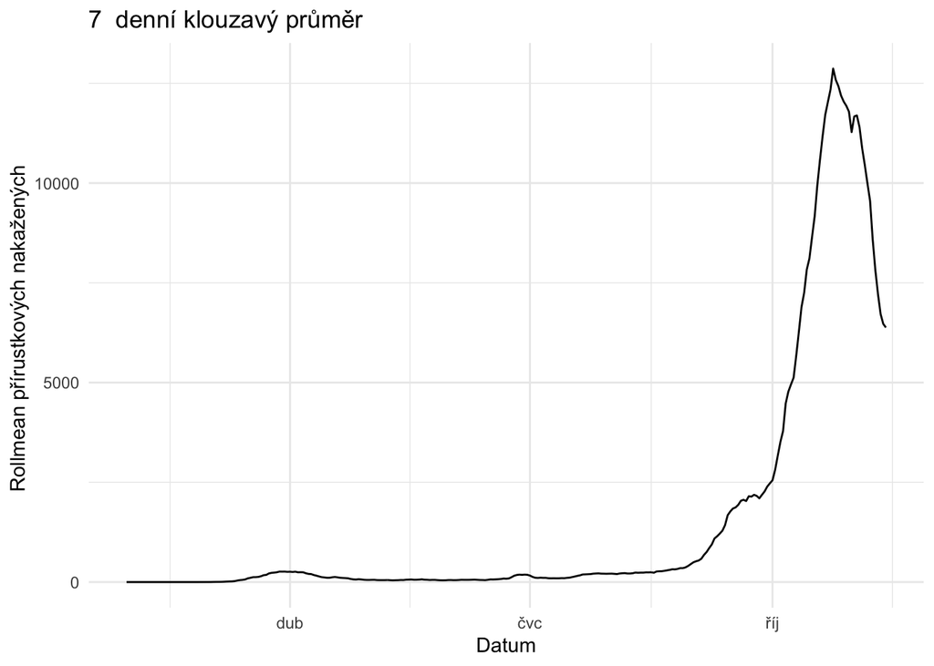

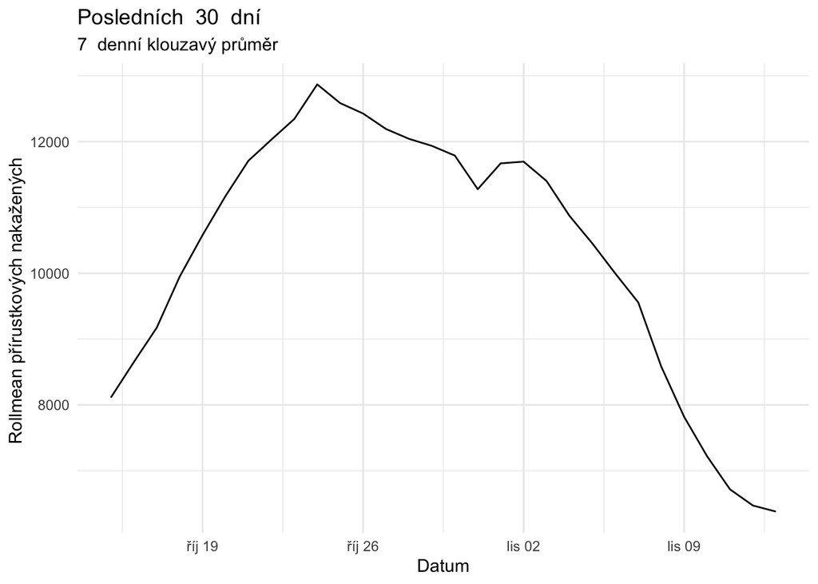

## Podíl pozitivních testů

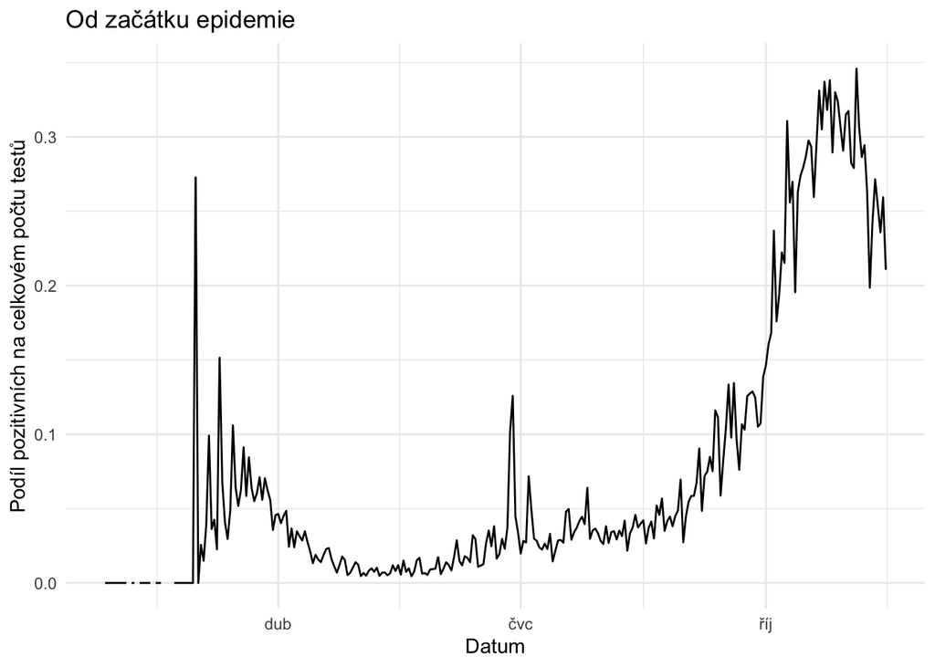

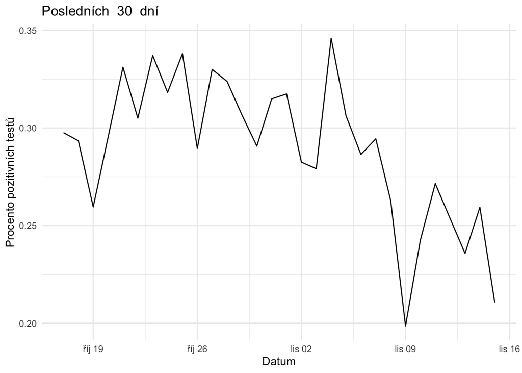

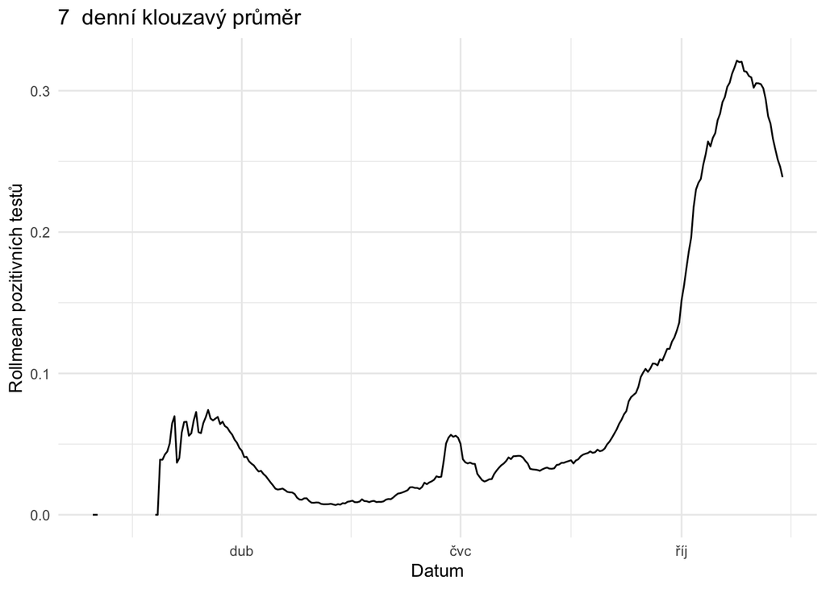

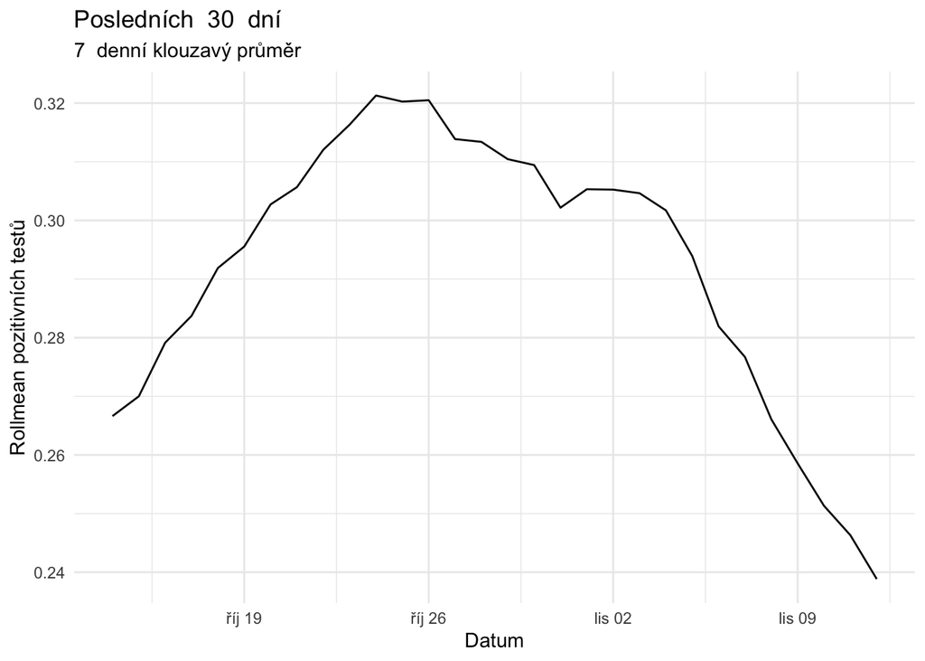

Podíl pozitivních testů na celkovém počtu od začátku epidemie je `16.706` %.

Podíl pozitivních testů na celkovém počtu za posledních 30 dní je `29.143` %.

# Modely

## Linearní model

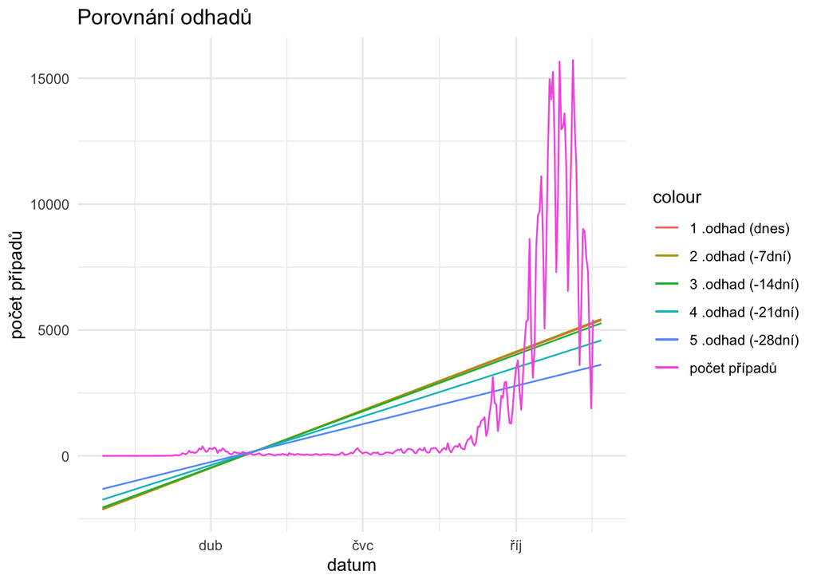

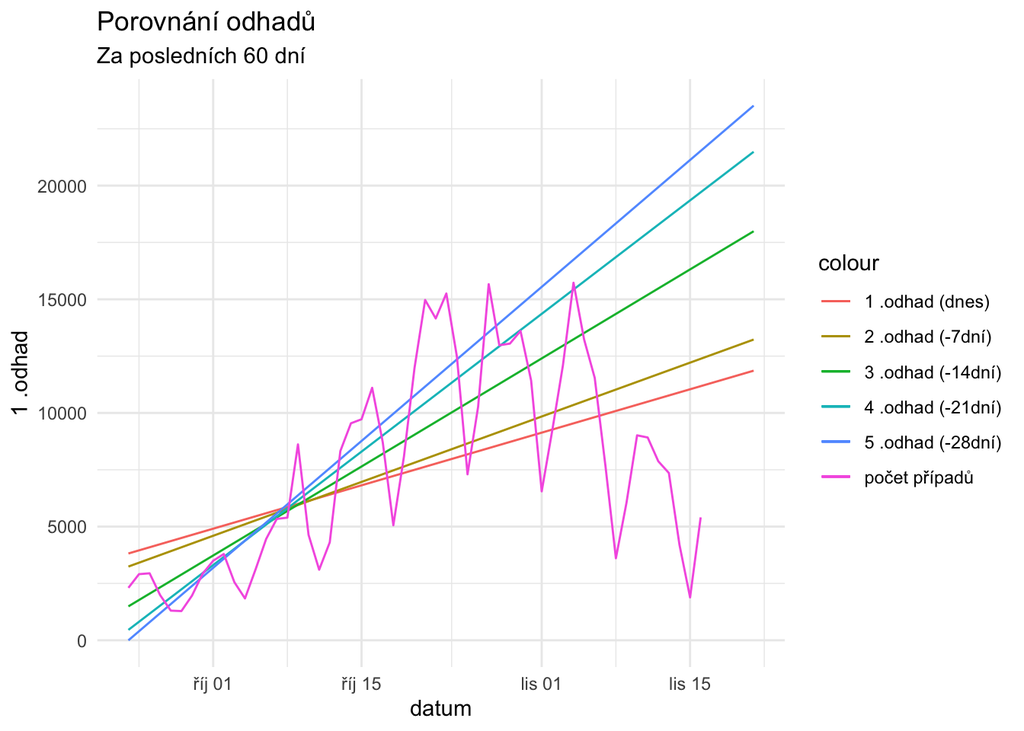

### Data (Lineární model)

#### Od začátku epidemie

Podle lineárního modelu bychom tímto tempem měli dne `2020-11-21` podle

- 1. odhadu `5392` nakažených denně
- 2. odhadu `5437` nakažených denně
- 3. odhadu `5273` nakažených denně
- 4. odhadu `4589` nakažených denně
- 5. odhadu `3625` nakažených denně

#### Za posledních `60` dní

Podle lineárního modelu bychom tímto tempem měli dne `2020-11-21` podle

- 1. odhadu `11859` nakažených denně
- 2. odhadu `13228` nakažených denně
- 3. odhadu `17992` nakažených denně
- 4. odhadu `21488` nakažených denně
- 5. odhadu `23518` nakažených denně

## Kvadratický model

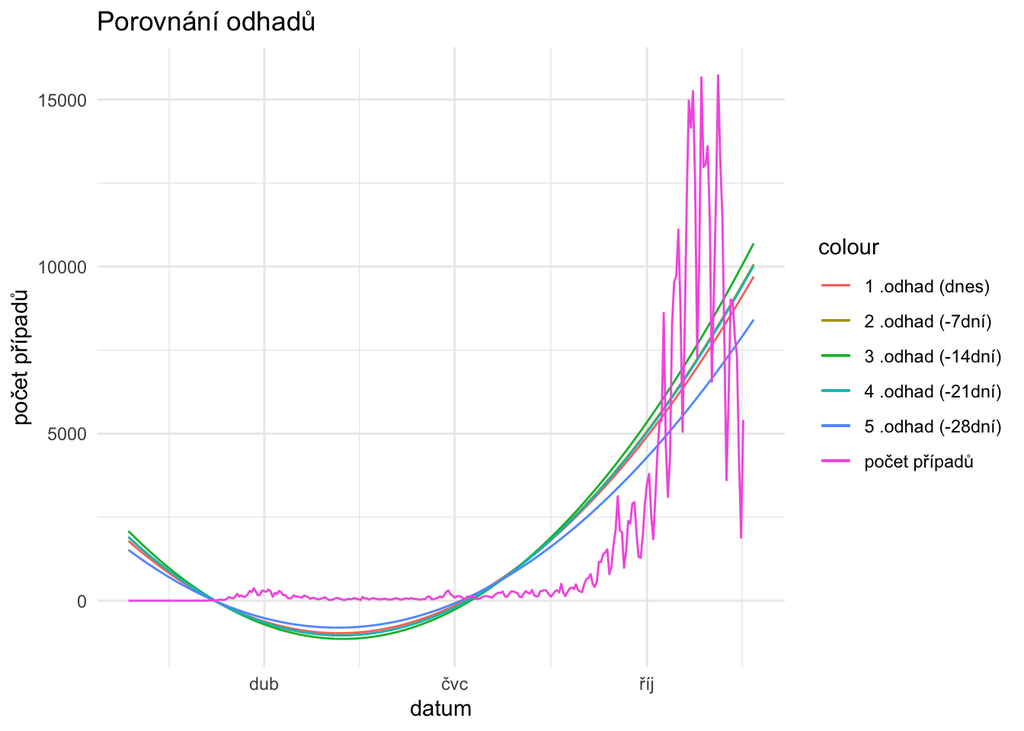

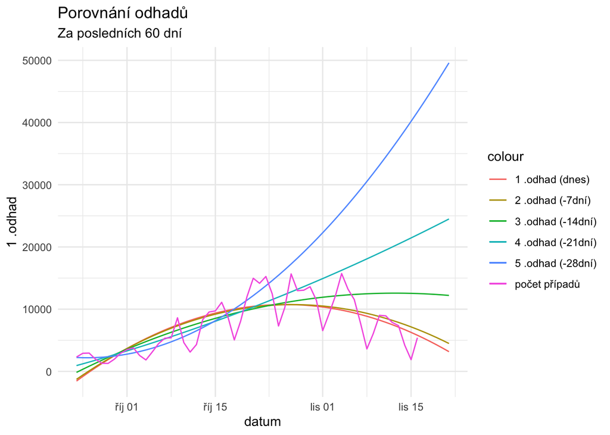

### Data (Kvadratický model)

#### Od začátku epidemie

Podle kvadratického modelu bychom tímto tempem měli dne `2020-11-21` podle

- 1. odhadu `9700` nakažených denně
- 2. odhadu `10070` nakažených denně
- 3. odhadu `10696` nakažených denně
- 4. odhadu `10025` nakažených denně
- 5. odhadu `8412` nakažených denně

#### Za posledních `60` dní

- 1. odhadu `3170` nakažených denně
- 2. odhadu `4486` nakažených denně
- 3. odhadu `12211` nakažených denně
- 4. odhadu `24495` nakažených denně
- 5. odhadu `49589` nakažených denně

## Exponential model

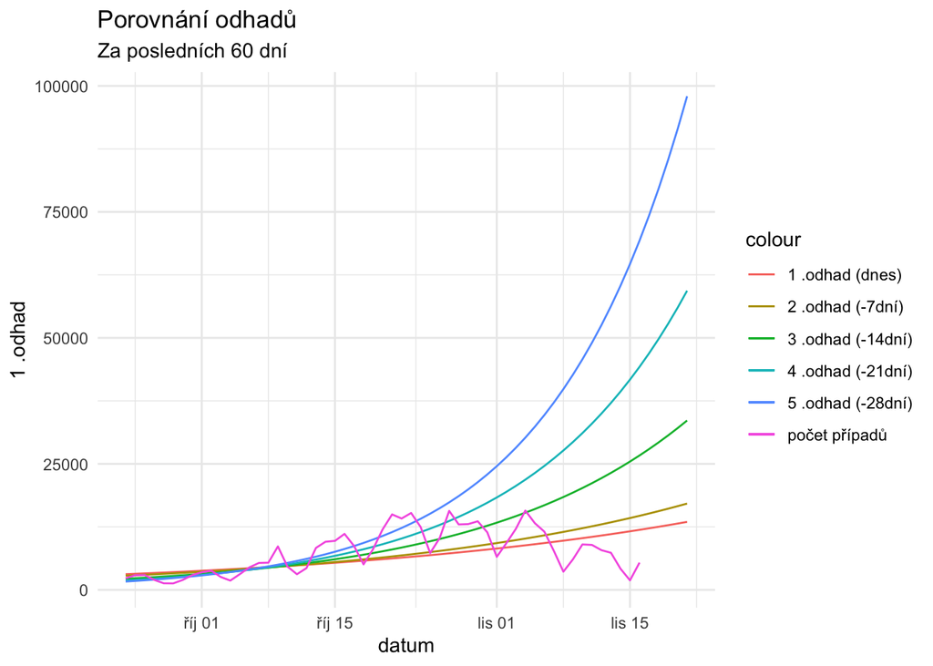

### Data (Exponential model)

#### Za posledních `60` dní

Podle exponencionálního modelu bychom tímto tempem měli dne `2020-11-21` podle

- 1. odhadu `13488` nakažených denně
- 2. odhadu `17122` nakažených denně
- 3. odhadu `33603` nakažených denně
- 4. odhadu `59359` nakažených denně
- 5. odhadu `97950` nakažených denně

Podle exponencionálního modelu bychom tímto tempem měli dnes dne `2020-11-17` podle

- 1. odhadu `12210` nakažených denně
- 2. odhadu `15149` nakažených denně
- 3. odhadu `27928` nakažených denně
- 4. odhadu `46927` nakažených denně
- 5. odhadu `74262` nakažených denně

# Informace

Update proběhl `2020-11-17 14:48:59`.

Poslední data jsou z `2020-11-16` ze stránek ministerstva zdravotnictví ČR (https://onemocneni-aktualne.mzcr.cz/covid-19)